# Income Data Quality Report

Author: Amira Shlebik** | **Email: amira.shlebik@northumbria.ac.uk** | **Student ID: w25026700

Date: 2026-01-15** | **Word Count: 3148

# 1 Overview

## 1.1 Project & Dataset Descriptions

- This report assesses the quality of the Income dataset, used to predict whether an individual’s annual income exceeds $50K. The assessment focused on the dataset’s structure, completeness, and integrity. It is structured into two phases: integrity checks and descriptive statistics.
- The dataset, Income.csv, contains 11 features and 10k rows, including personal, employment, and financial data. Key variables include age, education, workclass, occupation, and hours-per-week. The response variable, income, is binary, indicating whether the individual earns more than $50K/year. This dataset represents a binary classification problem, as the goal is to predict the value of a binary target variable.

## 1.2 Objective

The objective of this assessment is to evaluate the dataset’s quality, identifying missing values, inconsistencies, or any irregularities to guide necessary pre-processing before the modeling phase.

# 2 Dataset Structure & Metadata

## 2.1 Schema & Data Types

```
'data.frame':   10000 obs. of  11 variables:
 $ age           : int  25 38 28 44 18 34 29 63 24 55 ...
 $ workclass     : chr  " Private" " Private" " Local-gov" " Private" ...
 $ education     : chr  " 11th" " HS-grad" " Assoc-acdm" " Some-college" ...
 $ education.num : int  7 9 12 10 10 6 9 15 10 4 ...
 $ marital.status: chr  " Never-married" " Married-civ-spouse" " Married-civ-spouse" " Married-civ-spouse" ...
 $ occupation    : chr  " Machine-op-inspct" " Farming-fishing" " Protective-serv" " Machine-op-inspct" ...
 $ relationship  : chr  " Own-child" " Husband" " Husband" " Husband" ...
 $ race          : chr  " Black" " White" " White" " Black" ...
 $ sex           : chr  " Male" " Male" " Male" " Male" ...
 $ hours.per.week: int  40 50 40 40 30 30 40 32 40 10 ...
 $ Income        : Factor w/ 2 levels " <=50K."," >50K.": 1 1 2 2 1 1 1 2 1 1 ...
```

The dataset has **11** columns, **3** numeric, **8** categorical, no other types

## 2.2 Technical Validity

### 2.2.1 Type Mismatch

```
No numeric or date values are stored incorrectly as text.
```

### 2.2.2 Empty Rows & Empty Columns

```
No empty rows or columns detected.
```

### 2.2.3 Missing Values (Overview)

The dataset is completely clean (no missing data).

# 3 Descriptive Statistics

## 3.1 Numerical Features

|  | n | mean | sd | median | min | max | range | skew | kurtosis | rse_perc |
| --- | --- | --- | --- | --- | --- | --- | --- | --- | --- | --- |
| age | 10000 | 38.75 | 13.87 | 37 | 17 | 90 | 73 | 0.55 | -0.27 | 0.36% |
| education.num | 10000 | 10.07 | 2.57 | 10 | 1 | 16 | 15 | -0.34 | 0.64 | 0.26% |
| hours.per.week | 10000 | 40.46 | 12.42 | 40 | 1 | 99 | 98 | 0.29 | 3.10 | 0.31% |

### 3.1.1 Statistical Insights

**age (n=10,000)**

- The distribution is **right-skewed (skewness = 0.55)**, With a median of **37**, a mean of **38.75**, and a range of **17** to **90**. This suggests the data is concentrated around younger ages. However, further visualization is needed to confirm this and to determine whether the higher ages are true outliers pulling the distribution to the right and causing the skewness, or just a normal part of the data.
- The distribution is **platykurtic (kurtosis = -0.27)**, indicating lighter tails and fewer extreme outliers than a normal distribution.
- **RSE (0.36%):** Comparing to the sample mean, RSE is low; the sample mean is reliable.

**Overall Precision**

All numerical features demonstrate **RSE < 0.5%**, well within the **Agency for Healthcare Research and Quality (AHRQ) precision standard of 30%** (Agency for Healthcare Research and Quality, n.d.). This high precision, resulting from the large sample size (n=10,000), ensures the sample means are excellent estimates of population mean (μ). Population mean can be reliably estimated using 95% confidence intervals: CI = x̄ ± (SE * 1.96)

## 3.2 Categorical Features

### workclass

| Category | Count | Percentage |
| --- | --- | --- |
| Private | 6843 | 68.4% |
| Self-emp-not-inc | 813 | 8.1% |
| Local-gov | 633 | 6.3% |
| ? | 603 | 6% |
| State-gov | 444 | 4.4% |
| Self-emp-inc | 369 | 3.7% |
| Federal-gov | 290 | 2.9% |
| Without-pay | 4 | 0% |
| Never-worked | 1 | 0% |

### education

| Category | Count | Percentage |
| --- | --- | --- |
| HS-grad | 3238 | 32.4% |
| Some-college | 2203 | 22% |
| Bachelors | 1651 | 16.5% |
| Masters | 567 | 5.7% |
| Assoc-voc | 432 | 4.3% |
| 11th | 380 | 3.8% |
| Assoc-acdm | 330 | 3.3% |
| 10th | 284 | 2.8% |
| 7th-8th | 199 | 2% |
| Prof-school | 155 | 1.6% |
| 9th | 149 | 1.5% |
| 12th | 127 | 1.3% |
| Doctorate | 111 | 1.1% |
| 5th-6th | 103 | 1% |
| 1st-4th | 51 | 0.5% |
| Preschool | 20 | 0.2% |

### marital.status

| Category | Count | Percentage |
| --- | --- | --- |
| Married-civ-spouse | 4501 | 45% |
| Never-married | 3357 | 33.6% |
| Divorced | 1343 | 13.4% |
| Widowed | 344 | 3.4% |
| Separated | 311 | 3.1% |
| Married-spouse-absent | 135 | 1.4% |
| Married-AF-spouse | 9 | 0.1% |

### occupation

| Category | Count | Percentage |
| --- | --- | --- |
| Prof-specialty | 1269 | 12.7% |
| Exec-managerial | 1265 | 12.7% |
| Craft-repair | 1230 | 12.3% |
| Adm-clerical | 1116 | 11.2% |
| Sales | 1109 | 11.1% |
| Other-service | 1006 | 10.1% |
| Machine-op-inspct | 645 | 6.4% |
| ? | 604 | 6% |
| Transport-moving | 447 | 4.5% |
| Handlers-cleaners | 435 | 4.3% |
| Farming-fishing | 316 | 3.2% |
| Tech-support | 297 | 3% |
| Protective-serv | 199 | 2% |
| Priv-house-serv | 59 | 0.6% |
| Armed-Forces | 3 | 0% |

### relationship

| Category | Count | Percentage |
| --- | --- | --- |
| Husband | 3972 | 39.7% |
| Not-in-family | 2614 | 26.1% |
| Own-child | 1570 | 15.7% |
| Unmarried | 1067 | 10.7% |
| Wife | 456 | 4.6% |
| Other-relative | 321 | 3.2% |

### race

| Category | Count | Percentage |
| --- | --- | --- |
| White | 8579 | 85.8% |
| Black | 952 | 9.5% |
| Asian-Pac-Islander | 284 | 2.8% |
| Amer-Indian-Eskimo | 101 | 1% |
| Other | 84 | 0.8% |

### sex

| Category | Count | Percentage |
| --- | --- | --- |
| Male | 6674 | 66.7% |
| Female | 3326 | 33.3% |

### Income

| Category | Count | Percentage |
| --- | --- | --- |
| <=50K. | 7643 | 76.4% |
| >50K. | 2357 | 23.6% |

## 3.3 Feature Cardinality and Balance

| Column | # Cat. | Dominant Cat. (>50%) | Rare Cat. (each < 5%) | Total Noise | Group Recommendation |
| --- | --- | --- | --- | --- | --- |
| education | 16 | None | Assoc-voc, 11th, Assoc-acdm, 10th, 7th-8th, Prof-school, 9th, 12th, Doctorate, 5th-6th, 1st-4th, Preschool | High (>20%) | Domain grouping |
| occupation | 15 | None | Transport-moving, Handlers-cleaners, Farming-fishing, Tech-support, Protective-serv, Priv-house-serv, Armed-Forces | Moderate (10–20%) | Domain grouping |
| workclass | 9 | Private | State-gov, Self-emp-inc, Federal-gov, Without-pay, Never-worked | Moderate (10–20%) | Domain grouping |
| marital.status | 7 | None | Widowed, Separated, Married-spouse-absent, Married-AF-spouse | Low (<10%) | Domain grouping |
| relationship | 6 | None | Wife, Other-relative | Low (<10%) | Domain grouping |
| race | 5 | White | Asian-Pac-Islander, Amer-Indian-Eskimo, Other | Low (<10%) | Keep as-is |
| sex | 2 | Male | None | No Noise | Keep as-is |
| Income | 2 | <=50K. | None | No Noise | Keep as-is |

### 3.3.1 Interpretation and Grouping Strategy

The summary descriptive table shows that half of the categorical features in this dataset have many small categories, which can negatively impact the model’s performance.

**Cons of Small Categories:**

- **Visual Noise:** Plotting these features produces cluttered charts.
- **Overfitting Risk:** Small categories increase the risk of overfitting because the model learn patterns from them.
- **Skewness:** Too many small categories can skew the data distribution.

**Pros of Grouping:**

- **Enhanced Clarity:** Merging into broader categories makes the distribution more clear and easy to read.
- **Better Summarization:** The descriptive table becomes more concise, highlighting only the most impactful dominant and rare categories.
- **Enhanced Performance:** Grouping reduces multi-cardinality and skewness, which leads to more robust model performance.

**How grouping is performed:**

**Target Variable Analysis (Class Imbalance)**:

The target variable **(Income)** shows a **signifiant class imbalance**, with the majority class **(<=50K)** representing **76.4%** of the dataset. **Imbalanced classes** have a very **negative impact on model’s performance**, as they can cause models to become bias toward the majority class, consequently, the model can easily **achieve 76.4% accuracy by predicting <=50K for all observations**.

Hence, we need to consider resampling (oversampling-undersampling) or evaluate performance using metrics other than accuracy, such as Precision, Recall, and F1-Score. However, it is best to plot these features first to visualize the distribution and decide on the most logical strategies to deal with the issues of multi-cardinality and the imbalanced distributions.

## 3.4 Univariate Distributions

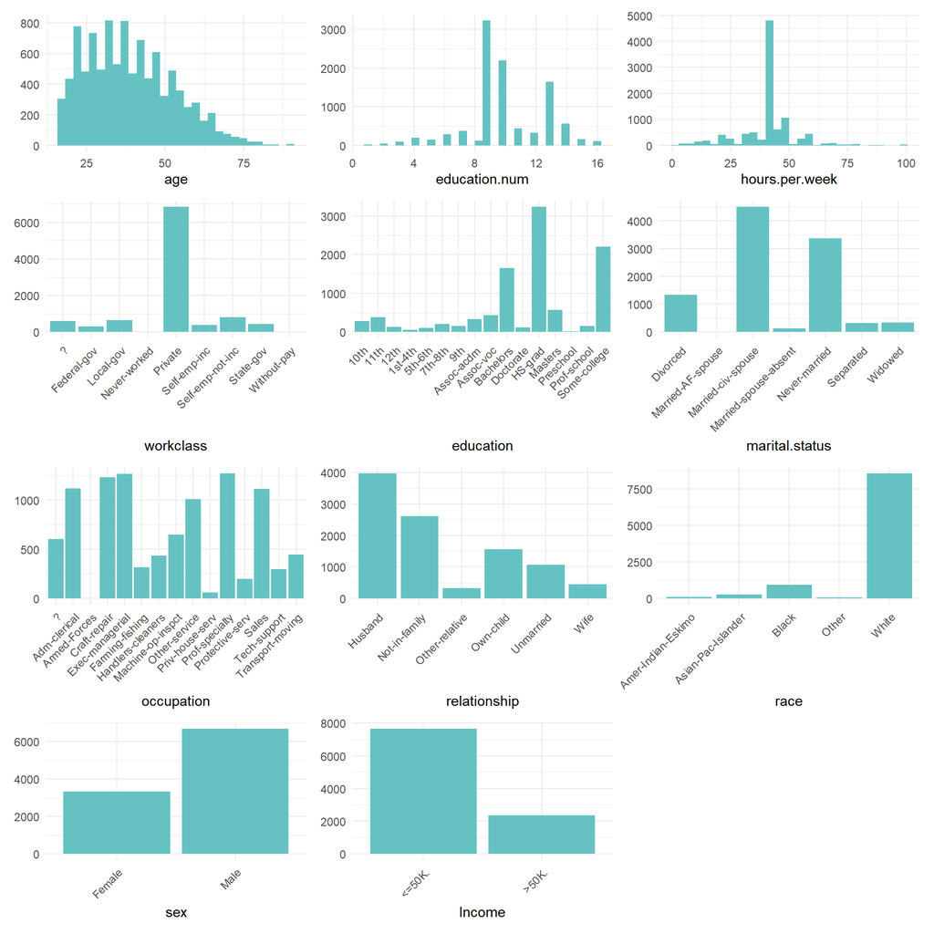

### 3.4.1 Distribution Highlights

Reviewing the distributions confirms earlier findings and reveals further patterns:

**1. Skewness Patterns**

- Right-Skewed: As previously observed, Age is right-skewed. Relationship and Income are the same.
- Left-Skewed: Education and Race. Their skewness is probably a result from their imbalanced distribution.
- Symmetric distributions: Education-Num and Hours-per-Week shows relatively balanced distributions around their means.

**2. Multi-Cardinality**

Except for Race and Sex, all categorical features have high cardinality and need dimensionality reduction.

**3. Class imbalance**

Except for Age and Sex, all features exhibit significant class imbalance.

# 4 Integrity & Completeness Checks

## 4.1 Missing Values (Detailed)

### 4.1.1 Missing Values by Column

```
No columns contain missing values.
```

### 4.1.2 Missing Values by Row

```
No rows contain missing values.
```

## 4.2 Duplicate Records

**588** duplicated rows found.  
These duplicates may lead to **skewed analysis** or **biased models.**

## 4.3 Special Characters

```
The following columns contain characters outside the acceptable set:
```

| Column | Chars_Found | Percentage |
| --- | --- | --- |
| workclass | ? | 6% |
| occupation | ? | 6% |

# 5 Anomalies & Outliers

## 5.1 Value Range validation

```r
check_value_ranges <- function(df) {
  issues <- list()

  if ("Age" %in% names(df)) {
    invalid_age <- sum(df$Age < 0 | df$Age > 120, na.rm = TRUE)
    if (invalid_age > 0) issues$Age <- invalid_age
  }

  if ("date" %in% names(df)) {
    min_d <- as.Date("1900-01-01")
    max_d <- as.Date("2050-12-31")
    valid_dates <- df$date[!is.na(df$date)]
    viol <- sum(valid_dates < min_d | valid_dates > max_d, na.rm = TRUE)
    if (viol > 0) issues$date <- viol
  }

  issues
}
```

[output not shown]

## 5.2 Outliers: Detection (IQR), Visualization (Boxplots) & Interpretation

| Column | Count |
| --- | --- |
| hours.per.week | 2721 |
| education.num | 373 |
| age | 41 |

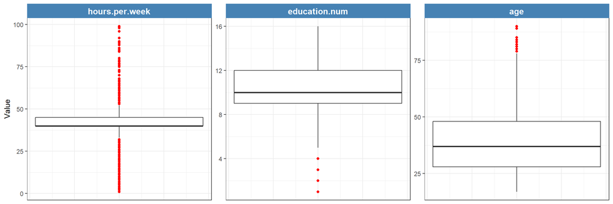

# 6 Data Issues & Bivariate Analysis

## 6.1 Data Issues

Till this point of our EDA, we have been able to identify these issues:

- Skewed data
- Multi-cardinality
- Imbalanced-class
- Duplicated data
- Special Characters
- Outliers

The only issues we **can** and **should** handle now are duplicated data and special characters as they will hinder our progress, as for the other issues, before deciding on how to handle them, we still have one last thing to do; **Bivariate Analysis** (visualizing feature’s relationships with the target).

## 6.2 Noise Reduction

### 6.2.1 Removing Duplicates

- **Dataset Total Rows: 10000**
- **Duplicate Rows:** 588
- **Final Count:** 9412

```r
df <- remove_duplicate(df)
```

- **Result:** All identical rows removed; only distinct records kept.

### 6.2.2 Replacing Special Characters

- **Columns Processed:** All character columns
- **Characters Found:** ‘?’
- **Replacement Value:** ‘Unknown’

```r
df <- replace_special_char(df)
```

- **Result:** Leading & trailing whitespace trimmed and **‘?’** renamed to **‘Unknown’**.

## 6.3 Bivariate Analysis: Identifying Key Predictors

Bivariate analysis examines the relationship between two variables; a predictor and a target. It’s not about fixing the data, rather it’s about deciding what is useful for the model.

Analyzing the relationship with the target helps in:

**1. Feature Selection:** Identify which features have a clear relationship with the target and prioritize them for machine learning models, while dropping features with weak connection with the target, especially if they are highly skewed or imbalanced.

**2. Grouping:** Group categories that have similar target probabilities.

### 6.3.1 Income Distribution by Numerical Features

**Guidance for Identifying Strong Predictors:**  
• Features with **significantly different medians** across target classes **→ Strong predictor**  
• Features with **little to no overlapped boxes → Strong predictor**  
• **Outliers concentrated in one target class → Important data**, not errors to be removed

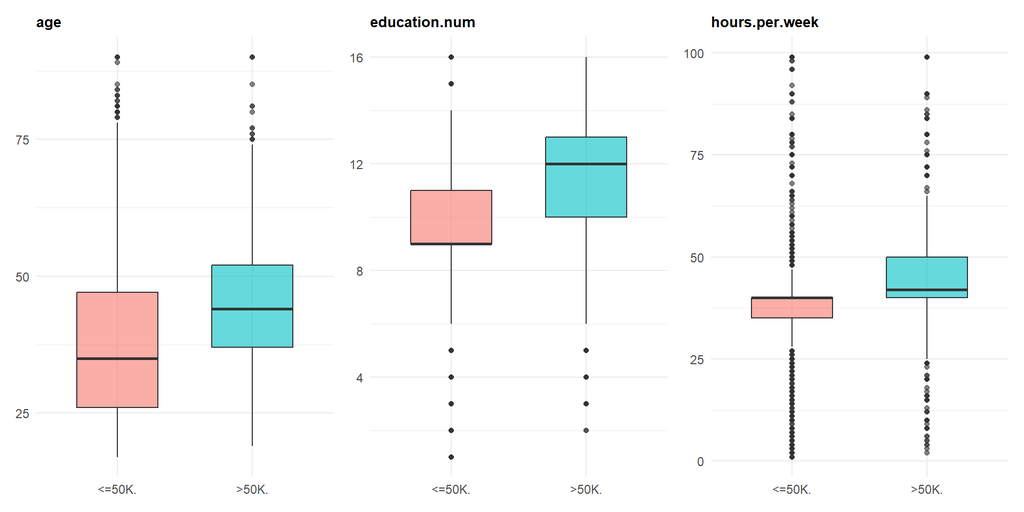

**Findings:**  
• The lower-income group **<=50k** is generally **younger** with **less education**, while the higher-income group **>50k** tend to be **older** and **highly educated**.  
• The **<=50k** group works a **typical 40 hrs/week**, whereas the **>50k** group **works more**, with a median of **43 hrs/week**.  
• **Age, education.num** and **hours.per.week** are all **strong** predictors.  
• In all features, the lower-income **<=50k** class contained significantly **more outliers** than the higher-income class **>50k.**

### 6.3.2 Income Distribution by Categorical Features

**Guidance for Identifying Strong Predictors:**  
• Features whose categories (bars) exhibit **significant variance or deviate greatly from the average target distribution → Strong predictor**  
• Categories with **~0 deviation from the average target distribution → Weak predictors**. They should be **grouped into an ‘Other’ category to reduces noise and prevent overfitting**

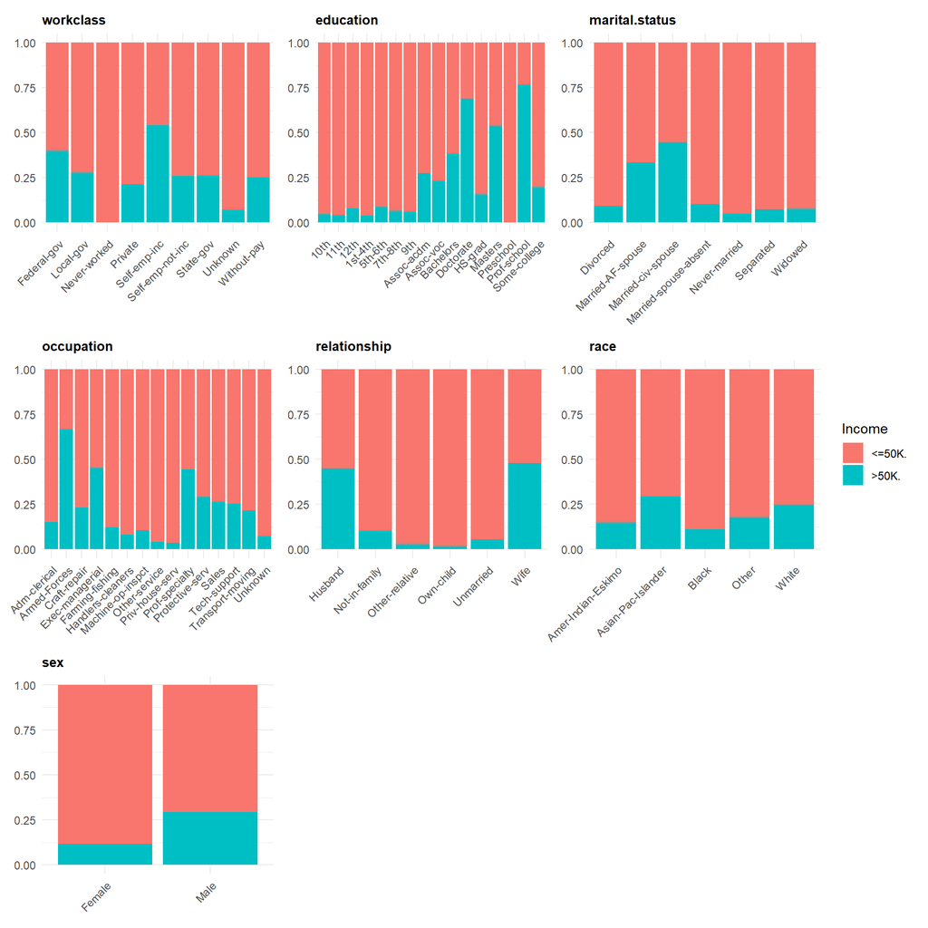

# 7 From Exploratory Data Analysis (EDA) to Feature Engineering (FE)

**EDA and bivariate analyses** were used to identify **data quality issues** and **strong predictors**, guiding the **creation of interaction features** and **feature transformation decisions** aimed at improving **model performance.**

| Issue | Col | Predictor | Col Type | Proposed Action |
| --- | --- | --- | --- | --- |
| **Right Skew** | Age | Strong | Mix | Experiment with: Raw (model as it is) log transform (Logp1) Box-Cox Replace with binary feature for Age |
| **Left Skew** | Education | Strong | Categoric | Nothing. The skewness is probably due to its imbalanced distribution. |
| **Multi-Cardinality** | Marital Status Work-class Education Occupation Relationship | Strong | Categoric | Do in order: 1. Domain-Knowledge 2. Collapse Rare categories 3. Merge categories with similar target deviation 4. Re-visualize distribution |
| **NA** | Education Num hours.per.week |  | Numeric | Do in order: 1. Group/Bin 2. Re-visualize to check imbalance is reduced |
| **NA** |  |  |  |  |
| **Outliers** | Age Education Num hours.per.week | Strong | Numeric | After skew and imbalance issues fixed: - Re-visualize outliers - Try Capping or Imputation. |
| **Special Char** | Work-class Occupation | Strong | Categoric | Replaced ? with ‘Unknown’ |
| **Duplicates** | All | NA | All | Removed |
| **Target imbalance** | Income | NA | Boolean | Experiment with: - Over sampling (SMOTE) - Under sampling - Class Weights |

## 7.2 Treatment of Outliers (Capping)

The EDA summary shows that **age**, **education.num**, and **hours.per.week** contain moderate to high outliers. To reduce extremes while maintaining the overall distribution, these values will be capped using **IQR fences**.

```r
cap_outliers <- function(df, cols_to_cap) {

   # Only numeric cols
  cols_to_cap <- intersect(cols_to_cap, names(df))
  numeric_cols <- cols_to_cap[sapply(df[cols_to_cap], is.numeric)]

  # Cap a column using IQR
  cap_column_iqr <- function(x) {
    Q1 <- quantile(x, 0.25, na.rm = TRUE)
    Q3 <- quantile(x, 0.75, na.rm = TRUE)
    IQR_val <- Q3 - Q1

    lower <- Q1 - 1.5 * IQR_val
    upper <- Q3 + 1.5 * IQR_val

    x[x < lower] <- lower
    x[x > upper] <- upper
    return(x)
  }

  # Apply capping to all numeric columns
  df[numeric_cols] <- lapply(df[numeric_cols], cap_column_iqr)

  return(df)
}
```

## 7.3 Assessment of Outliers Capping

- **No remaining outliers** in the selected columns.

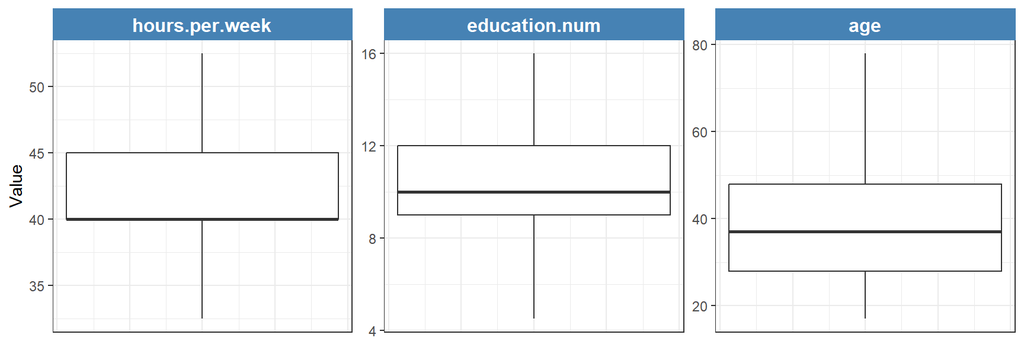

IQR-based capping is applied here to limit extreme values, protecting linear models while minimally affecting tree-based models. This standardizes our dataset so model comparisons reflect real performance, not outlier influence.

## 7.4 Treatment of Weak Features (Dropping)

```r
weak_cat <- c("Race","Sex")
df <-  df %>% select(all_of(weak_cat))
```

## 7.5 Feature Engineering

Binary and product features are created before any transformation is applied.

```r
if (length(strong_numeric) > 0) {

    col_age <- df_original[[strong_numeric[1]]]
    col_edu <- df_original[[strong_numeric[2]]]
    col_hrw <- df_original[[strong_numeric[3]]]

    # 1. Binary feature out of raw strong features (skewed or not)
    df_binary$is_old <- col_age >= 45
    df_binary$is_high_eduacted <- col_edu >= 12
    df_binary$is_overtime <- col_hrw >= 40


    # 2. Product feature out of raw strong features (skewed or not)
    df_prod_num$age_edu <- product_strong(col_age, col_edu)
    df_prod_num$age_hrw <- product_strong(col_age, col_hrw)
    df_prod_num$edu_hrw <- product_strong(col_edu, col_hrw)

}
```

## 7.6 Treatment of Skewness (Transformation)

Apply feature transformations to skewed numerical features when using linear models.

```r
# Check skew in Original cols
original_strong_numeric <- df_original[, strong_numeric]
original_skew_values <- sapply(original_strong_numeric, skewness, na.rm = TRUE)
skewed_orig_numeric <- names(original_skew_values[abs(original_skew_values) > 1.0])

# Check skew in product cols (the newly ones)
strong_product <- c("age_edu", "age_hrw", "edu_hrw")
product_features <- df_prod_num[, strong_product]
product_skew_values <- sapply(product_features, skewness, na.rm = TRUE)
skewed_product_numeric <- names(product_skew_values[abs(product_skew_values) > 1.0]) # Threshold = +-1.0

# Append these two together to apply needed transformations
all_skewed_numeric <- unique(c(skewed_orig_numeric, skewed_product_numeric))

for (col_name in all_skewed_numeric) {

  col <- if (col_name %in% names(df_original)) {
    df_original[[col_name]]
  } else {
    df_prod_num[[col_name]]
  }

  # log transform
  if (all(col > -1, na.rm = TRUE)) {
    df_log[[paste0(col_name, "_log")]] <- fix_skew_with_log1p(col)
  }

  # Box-Cox
  if (all(col > 0, na.rm = TRUE)) {
    df_cox[[paste0(col_name, "_cox")]] <- fix_skew_with_cox(col)
  }

}
```

## 7.7 Assessment of Transformations

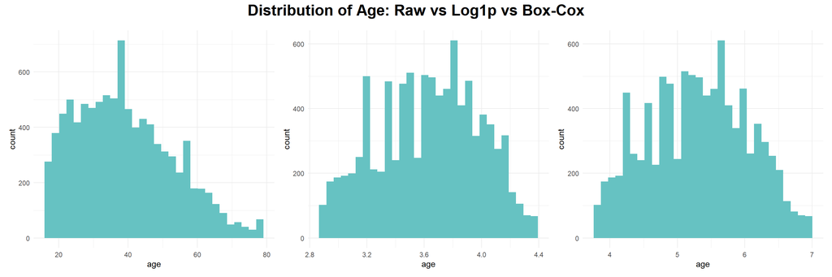

- **Outlier capping** compressed **extreme ages above 75** while **preserving the main distribution (25–45 years)**, reducing the influence of **rare elderly cases** without **distorting overall patterns**.
- The **Log1p** reduced **skew**, compressed **high values**, and made the distribution more **symmetric** and suitable for **models assuming normality**.
- The **Box-Cox** transformation made the data **symmetric, centered** around 5.0, and **reduced variance, effectively normalizing** it to **improve** linear model performance.
- However, to evaluate the impact of these transformations, we will **test tree-based, distance-based, linear, and neural network models** on all three **age representations (capped, log1p, box-cox)** and compare **accuracy, precision, recall**, and **F1-score** to identify the best **model-transformation combinations.**

## 7.8 Treatment of Multi-Cardinality & Imbalanced Distribution for Categorical Features

```r
# 1. Domain Knowledge Grouping to Capture meaningful categories before blind auto rare grouping
df_domain <- group_by_domain_knowledge(df_domain, strong_cat)

# 2. Rare Category Collapsing
df_rare <- df_domain
for(col in strong_cat){
  df_rare[[col]] <- collapse_rare(df_rare[[col]], threshold = 0.02, min_levels = min_levels)
}

# 3. Calculate categories deviations
target_val <- target_classes[2]
deviations_df <- calc_categories_deviations(df_rare,strong_cat,target_col,target_val,target_dist)

# 4. Merge categories based on deviation
merged_deviations <- merge_similar_categories(deviations_df)

# 5. Apply the newly merged categories to a new dataframe
df_dev <- df_rare
for(feature in strong_cat){
  df_dev <- apply_category_merges(df_rare, merged_deviations, feature, min_levels = min_levels)
}
```

## 7.9 Assessment of Feature Transformation on Categorical Features

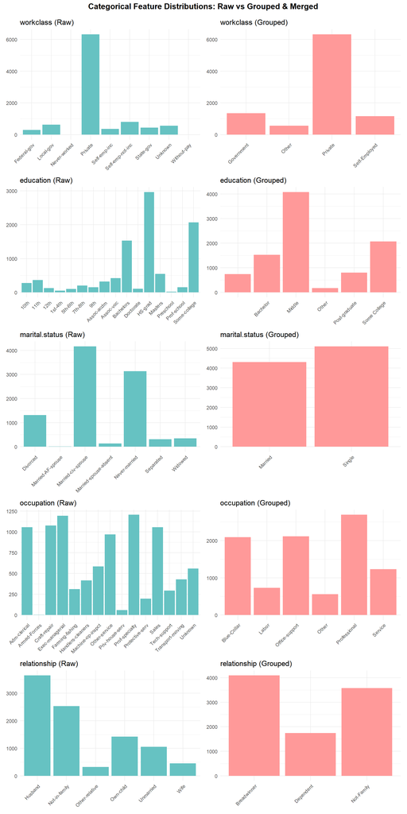

The plot demonstrates that transforming categorical features substantially improves **feature quality** and **model readiness** by reducing **high cardinality**, correcting **class imbalance**, and grouping **rare categories**.

## 7.10 Treatment of Class Imbalance (Upsampling)

He and Ma (2013) explain that classifiers trained on imbalanced data tend to favor the majority class. **Therefore, upsampling is used in this project to reduce class imbalance and improve minority-class prediction.**

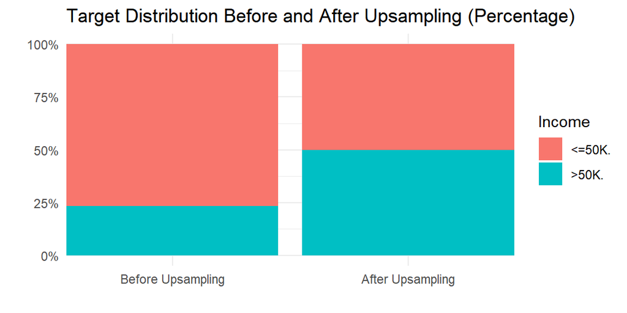

```r
train_balanced <- upSample(x = train %>% select(-all_of(target_col)),
                           y = train[[target_col]], yname = target_col)
train <- train_balanced
```

# 8 Models Evaluation

To assess how **feature engineering** and **algorithm choices** impact predictive performance, the following **evaluation framework** was implemented:

- **8 feature engineering strategies** tested
- **6 machine learning algorithms** evaluated
- **48 total model-experiment combinations**
- **80/20 train-test split** with **upsampling for class balance**
- **Evaluation metrics: AUC, Accuracy, F1, Precision, Recall**
- As this is a **classification task**, **AUC** is used as the **primary metric** to measure the model’s ability to distinguish between classes.

## 8.1 AUC Scores for Top-performing Models by Experiment

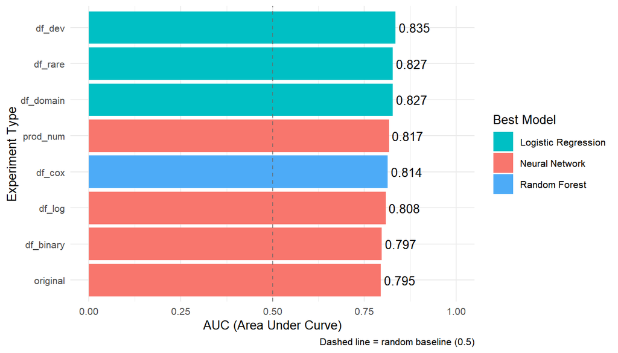

## 8.2 AUC Performance Across Models and Feature Engineering Strategies

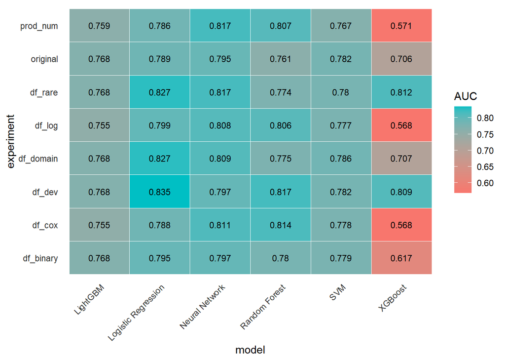

- Across **48 model–experiment combinations**, performance was driven mainly by **feature engineering choices** rather than model complexity.
- Applying **deviation-based merging after domain and rare grouping (df_dev)** with Logistic Regression achieved the highest AUC (**0.835**), outperforming earlier categorical transformations alone.
- **df_domain** and **df_rare** also **performed strongly**, confirming the importance of categorical feature treatment, while **Log/Box-Cox** transformations delivered only **marginal gains**.
- **Interaction features (prod_num)** improved Neural Network results, but **did not surpass** the best **AUC** achieved with simpler models and stronger feature design.

## 8.3 Model Stability: Mean Performance with Range

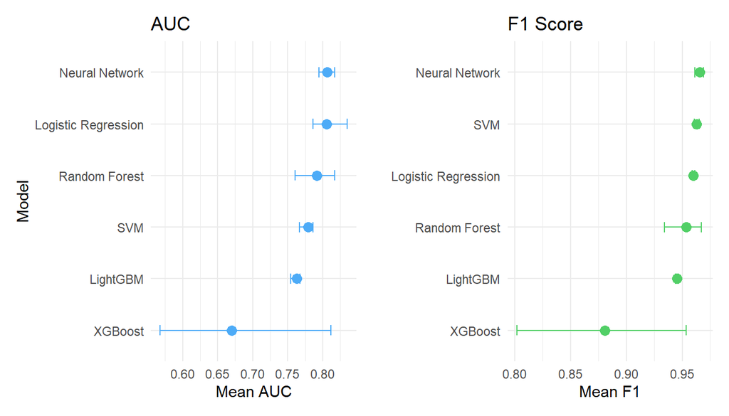

## 8.4 Model Selection

Random Forest maintained strong F1 scores (~0.94-0.96) with moderate stability, while XGBoost’s poor performance (mean AUC: 0.68) and wide variance indicate fundamental incompatibility with the tested preprocessing approaches.

**Final Model Recommendation: Logistic Regression with df_dev features**

Despite Neural Networks offering more consistent performance across experiments, Logistic Regression with df_dev features is recommended for production deployment based on:

- **Superior discriminative ability:** Highest AUC (0.835) demonstrates best ranking performance for identifying high-income individuals
- **Strong classification metrics:** 92.2% accuracy and 0.959 F1 score with perfect recall (1.0) ensuring no high-income cases are missed
- **Production efficiency:** Fast training and prediction times suitable for real-time applications
- **Acceptable stability:** While showing variance across feature sets, performance remains strong (>0.80 AUC) when proper feature engineering is applied

This recommendation assumes the **feature engineering pipeline (deviation-based merging after domain and rare grouping)** can be consistently maintained in production.

# 9 References

Barocas, S., Hardt, M. and Narayanan, A. (2023) Fairness and Machine Learning: Limitations and Opportunities. Available at: https://fairmlbook.org/pdf/fairmlbook.pdf (Accessed: 10 December 2025).

He, H. and Ma, Y. (eds.) (2013) Imbalanced Learning: Foundations, Algorithms, and Applications. Hoboken, NJ: Wiley-IEEE Press.

Kuhn, M. and Johnson, K. (2019) Feature Engineering and Selection: A Practical Approach for Predictive Models. Boca Raton, FL: CRC Press. Available at: http://www.feat.engineering/ (Accessed: 16 December 2025).

Agency for Healthcare Research and Quality (n.d.) MEPS HC Response Rates by Panel. Available at: https://meps.ahrq.gov/survey_comp/precision_guidelines.shtml (Accessed: 14 December 2025).